# Why synthesise evidence?

An introduction to systematic reviews, systematic maps and meta-analyses

Damien Beillouin

CIRAD, UPR HortSys

## Learning objectives

By the end of this session, you will be able to:

1. Explain **why a single study is not enough** to answer an applied question.
2. **Distinguish** a narrative review, a systematic map, a systematic review and a meta-analysis — and say what each can and cannot tell you.
3. Name the **standards** that make a synthesis trustworthy (CEE, Cochrane, PRISMA 2020, ROSES).
4. Place **each step of this week** in the workflow of a systematic review.

# Look closer, then step back

## One study…

What is this?

One can. Clear, precise, detailed.

[figure not shown]

## Many studies…

And now?

Many cans. Each one looks different.

[figure not shown]

## …and the big picture

Georges Seurat’s *A Sunday Afternoon on the Island of La Grande Jatte*, rebuilt from **106,000 cans**.

**One study = one can.**  
A synthesis reveals a pattern that no single study shows — but it can also **hide the details** of each can.

[figure not shown]

Chris Jordan, *Cans Seurat* (2007), series *Running the Numbers*: 106,000 aluminium cans, the number used in the US every 30 seconds.

# Our question: one study, or all of them?

## In medicine: one study, twelve children, one retraction

| Year | What happened |
| --- | --- |
| **1998** | Wakefield et al. (*The Lancet*): case series of **12 children**, suggests a link between the MMR vaccine and autism. Press conference, huge media coverage. |
| 1998–2004 | MMR vaccination coverage falls in the UK; measles returns. |
| 2004 | 10 co-authors retract the paper’s interpretation. |
| **2010–11** | *The Lancet* fully retracts the paper; Wakefield is struck off; the *BMJ* shows the data were **fraudulent**. |
| **2014** | Meta-analysis of 5 cohort (1.26 million children) and 5 case-control studies: **no association** between vaccination and autism. |

A single, vivid study small sample, no control group, conflicts of interest — but enormous influence.

The weight of evidence all eligible studies, weighted by their precision, appraised for bias.

Source: Wakefield et al. (1998); Godlee et al. (2011); Taylor et al. (2014) (cohorts: 1,256,407 children; case-control: 9,920).

## Our running example this week

The question Does **diversifying farms** (intercropping, agroforestry, rotations…) benefit **biodiversity** — without costing **yield**?

A published systematic map (Jones et al. 2021) (partly built from earlier meta-analyses):

- **1,590** records screened
- **237** studies · **4,076** comparisons
- **48** countries · 1986–2021

We use it **all week**: map, effect sizes, models, bias.

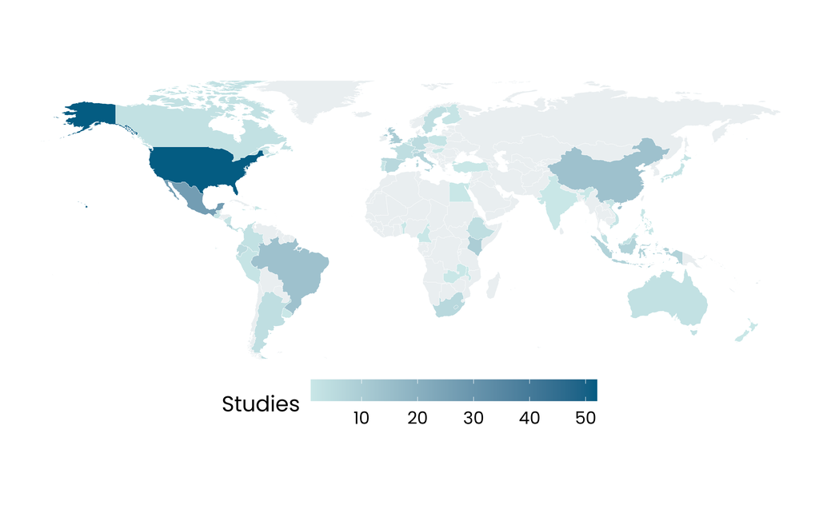

## Quick poll

Show of hands

Compared with a monoculture, does **intercropping** reduce the abundance of **crop pests**?

- Yes, clearly
- No
- It depends

## If you had read only one study…

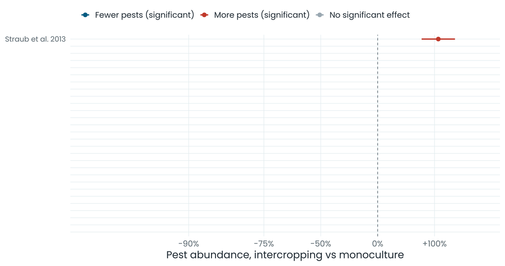

**Straub et al. 2013**: intercropping **increases** pest abundance (+109%). Conclusion: avoid intercropping?

## …or another one

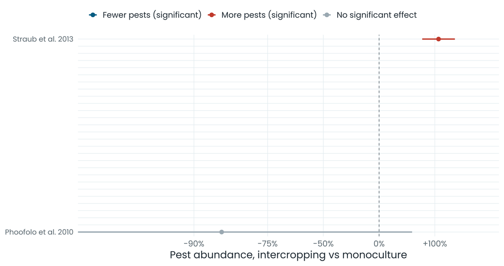

**Phoofolo et al. 2010**: intercropping **cuts** pests (-86%). Conclusion: intercrop everywhere?

## Primary studies disagree

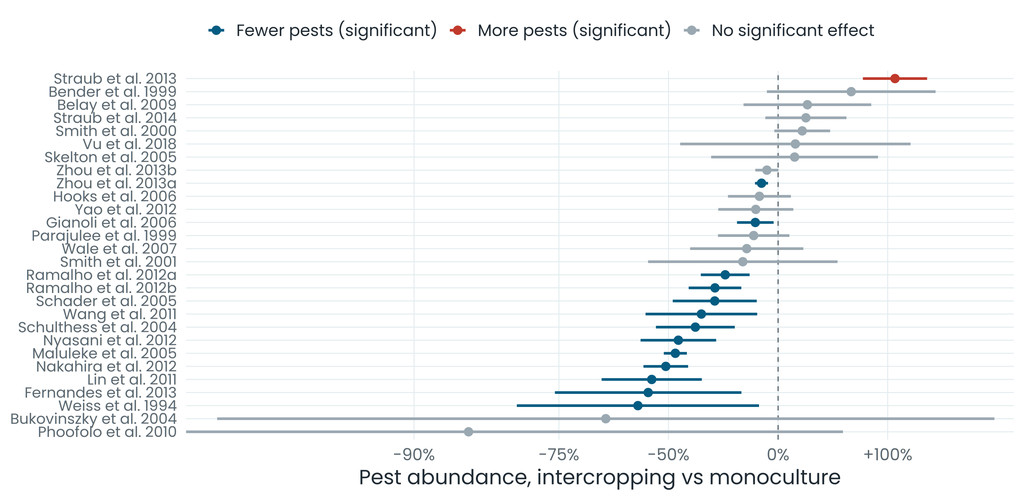

Source: 28 studies, 382 comparisons from Jones et al. (2021). One point per study (random-effects summary of its comparisons), 95% CI.

## A synthesis sees the pattern — and its spread

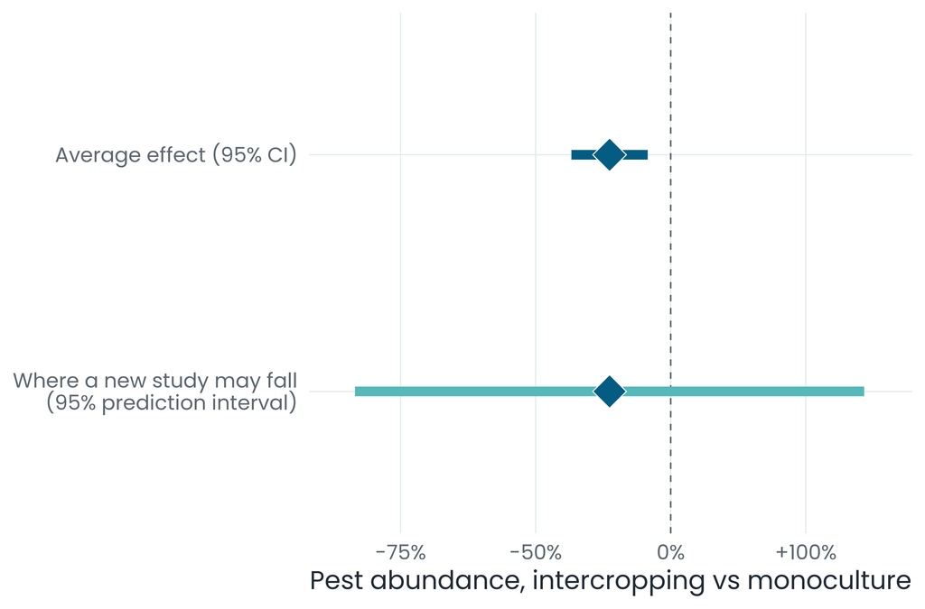

On average, intercropping **reduces pests by 27%**  
(95% CI: 11–40% reduction).

But in a new field, the effect could be anywhere from **-80%** to **+170%**.  
→ The honest answer to the poll was **“it depends”**.

Random-effects meta-analysis accounting for several comparisons per study: k = 382 comparisons, 28 studies. You will fit this model on Wednesday.

## Two intervals, two questions

Confidence interval (CI) *How precisely do we know the **average** effect?*

-40% to -11% → shrinks as studies accumulate.

Prediction interval (PI) *What effect should we expect in a **new field**?*

-80% to +170% → does **not** shrink to zero with more studies: it reflects **real differences** between sites, crops and pests.

Heterogeneity (τ²) The **spread of the true effects** (between studies, and between comparisons within studies). Here the true effect differs from field to field — which is why the PI is wide.

In ecology this is the rule, not the exception (Senior et al. 2016).

Report the mean **with** its prediction interval. Explaining the spread (crop, pest group, region) is the job of **moderators** — Wednesday afternoon.

# Why we need synthesis

## Too much to read

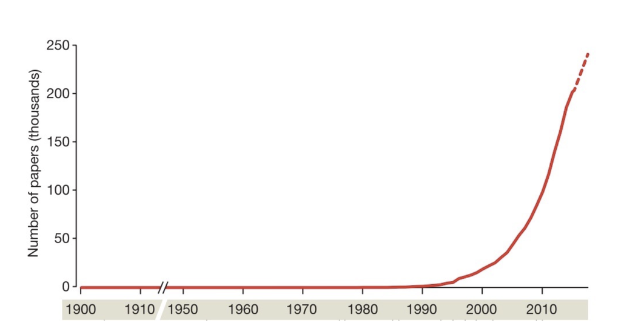

Publications grow exponentially — today **> 3 million** peer-reviewed articles per year across all sciences (Johnson et al. 2018).

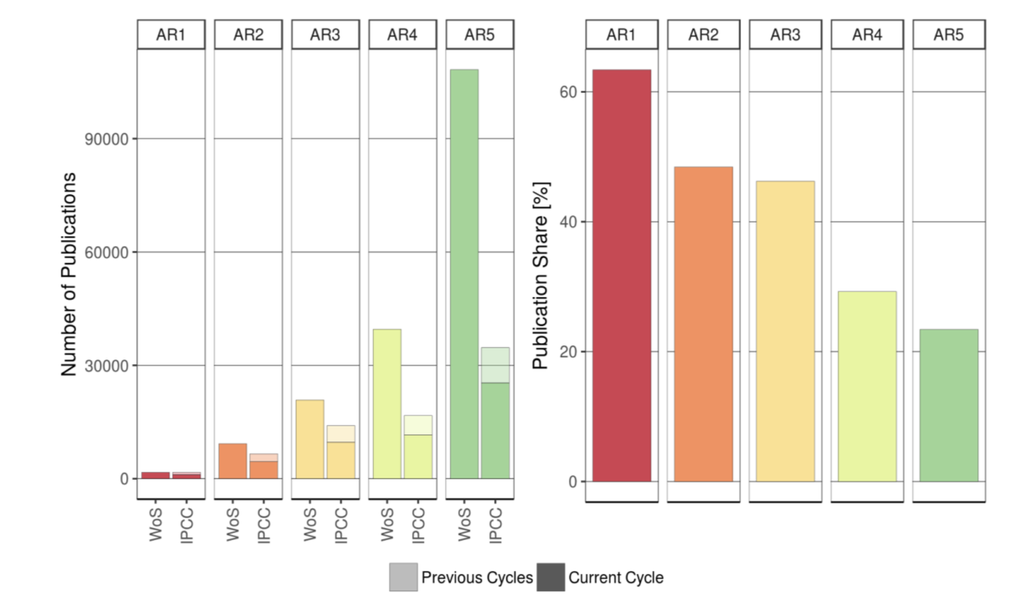

IPCC assessments cite a **shrinking share** of the relevant literature at each cycle.

Left: Gurevitch et al. (2018). Right: Minx et al. (2017).

## Syntheses boom…

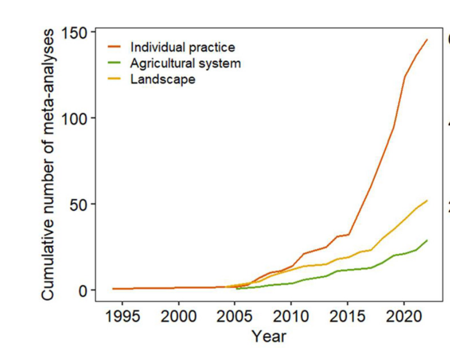

Cumulative number of meta-analyses on **crop diversification**, by scale of the practice.

Dozens of meta-analyses on crop diversification…  
Do they agree? Can we trust them?

Source: Beillouin et al. (2019) and updates.

## …but their quality varies

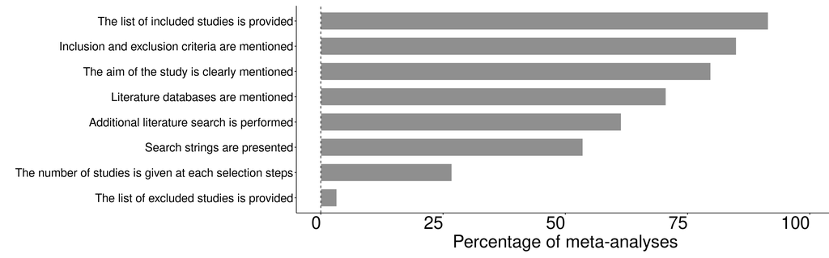

Share of meta-analyses on crop diversification reporting each item.

Reporting standards **PRISMA 2020** (Page et al. 2021)  
**PRISMA-EcoEvo** (O’Dea et al. 2021)  
**ROSES** (Haddaway et al. 2018)

Appraising a synthesis CEESAT (Woodcock et al. 2014)  
Ten appraisal questions (Nakagawa et al. 2017)

Source: Beillouin et al. (2019) and updates.

## How to conduct a synthesis: guidelines we follow this week

Guidelines **CEE** Guidelines and Standards, v5.1 (Collaboration for Environmental Evidence 2022) — environment  
**Cochrane** Handbook, v6.5 (Higgins et al. 2024) — health  
Campbell Collaboration — social sciences  
Environment: mostly field experiments and observational studies, strong spatio-temporal variability → expect heterogeneity.

Protocol registration **PROCEED** (environment) · PROSPERO (health) · OSF

Reference books Koricheva et al. (2013) · Borenstein et al. (2021)  
Harrer et al. (2021) (free online, R code)

## Garbage in, garbage out: appraise before you pool

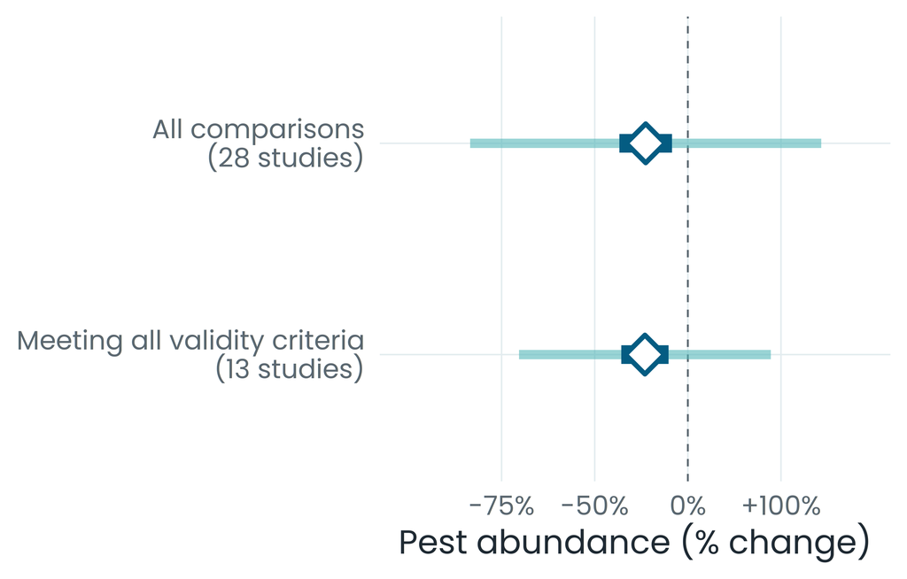

The authors of the map **appraised the comparisons** (replication, duration, distance between plots) — 130 of 382 could not be appraised.

Dark bar = 95% CI, light bar = 95% PI.  
Restricted to valid comparisons: **same mean** (−27%) and a narrower prediction interval — weaker designs may add noise (or the 13 remaining studies are simply more alike). Appraisal lets you **check** this.

You only know this because validity was **coded**. Reporting standards (PRISMA, ROSES) ≠ **critical appraisal** of each primary study — Wednesday morning.

# A jungle of terms

## Your turn

30 seconds · discuss with your neighbour

Review, systematic review, systematic map, meta-analysis: **what is the difference?**

## Describing the evidence

| Method | Question | What makes it distinctive | Output |
| --- | --- | --- | --- |
| **Narrative review** | Broad | Expert selection of studies; no explicit, reproducible method | Expert overview — prone to selection bias |
| **Scoping review** | Broad, exploratory | Maps concepts and types of evidence; usually no appraisal | Clarifies a field before a full review |
| **Systematic map** | Broad: *what is known?* | Systematic search and coding of the whole evidence base | Database + map of evidence **and gaps** |

Source: Collaboration for Environmental Evidence (2022); Grant and Booth (2009); James et al. (2016).

## Answering a question

| Method | Question | What makes it distinctive | Output |
| --- | --- | --- | --- |
| **Rapid review** | Focused, urgent | Systematic review with *declared* shortcuts (fewer databases, one screener) | Timely answer, lower certainty |
| **Systematic review** | Focused (PICO/PECO) | *A priori* protocol, comprehensive search, explicit eligibility, **critical appraisal**, transparent synthesis | Answer to the question, with its certainty |
| **Meta-analysis** | Quantitative | *Statistical* combination of effect sizes, weighted by precision | Mean effect, heterogeneity, moderators |

**Systematic review ≠ meta-analysis.** “Systematic” describes the **method**; meta-analysis is a **statistical tool**. Gold standard: a meta-analysis **within** a systematic review.

Source: Collaboration for Environmental Evidence (2022); Higgins et al. (2024). Umbrella reviews apply the same logic to existing reviews.

## Choosing a method

▶

▲

Aim: describe the evidence → quantify an effect

Rigour, transparency, effort

Narrative review

"Meta-analysis" of a convenience sample

Rapid review · Scoping review

**Systematic map**

**Systematic review** (narrative or quantitative synthesis)

**+ meta-analysis**

## Same database, two products

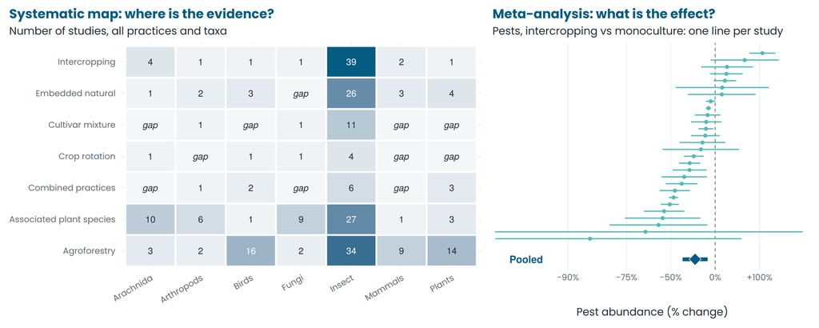

Both from Jones et al. (2021). The map counts studies for every practice and taxon (you build it on Tuesday); the meta-analysis pools one question, pests under intercropping (you fit it on Wednesday).

## Strengths and limits of meta-analysis

| Meta-analysis can… | …but it cannot |
| --- | --- |
| **See the forest for the trees** | Show every tree: the average can **mask contrasting effects** |
| **Quantify** heterogeneity (τ², prediction interval) | Make incomparable studies comparable: that is decided by the **question** |
| Estimate the **average effect** of a practice across the studied sites (when studies are experiments) | Turn **moderator** comparisons (between studies) into causal evidence |
| **Explore** small-study effects and test robustness | **Remove** bias from primary studies: *garbage in, garbage out* |

## The evidence pyramid, revisited

The classic pyramid puts meta-analyses **on top**. The revised pyramid (Murad et al. 2016):

- Syntheses are a **lens** through which primary evidence is viewed — not a level above it.
- Boundaries are **wavy**: a well-run observational study can beat a flawed experiment.

A synthesis is only as strong as the studies it contains **and** the method used to find and appraise them.

Adapted to ecology and agronomy from Murad et al. (2016).

## Which method for which question?

**A.** A ministry needs, **within 6 weeks**, an overview of whether hedgerows benefit pollinators.

**Rapid review** — with its shortcuts declared.

**B.** Which diversification practices, taxa and regions **have been studied**, and where are the gaps?

**Systematic map.**

**C.** **How much** does intercropping change pest abundance, and **why** does it vary?

**Systematic review with meta-analysis** (and moderators).

## Your week: one systematic review, step by step

**Mon**  
Question & stakeholders  
Protocol  
Search · Screening  
Full texts · Reporting

**Tue**  
Data visualisation  
From hypothesis to map  
Codebook  
**R practical: evidence maps**  
AI tools

**Wed**  
**Effect sizes** · appraisal  
Quantitative extraction  
**Models · bias**  
**Advanced methods**

**Thu**  
Group projects:  
do it yourself

**Fri**  
Presentations  
and feedback

Joseph · Sylvie · Nicolas

Joseph · Devi · Damien

Damien · Joseph

All

All

Workflow: Question→ Protocol→ Search→ Screen→ Extract & code→ Appraise→ Synthesise→ Report

## Key messages

1. **One study can mislead.** Decisions need the whole body of evidence.
2. **“Systematic” is a method** (protocol, exhaustive search, appraisal, transparency); **meta-analysis is a statistical tool**. They are not synonyms.
3. A **map** tells *where* the evidence is; a **meta-analysis** tells *what it says* — and how much it varies.
4. In ecology, **heterogeneity is the rule**: report the prediction interval, not only the mean.

## Glossary · English → French

| English | Français | English | Français |
| --- | --- | --- | --- |
| Evidence synthesis | Synthèse des connaissances | Effect size | Taille d’effet |
| Systematic review | Revue systématique | Forest plot | Graphique en forêt (*forest plot*) |
| Systematic (evidence) map | Carte systématique | Heterogeneity | Hétérogénéité |
| Scoping review | Revue exploratoire | Confidence interval | Intervalle de confiance |
| Rapid review | Revue rapide | Prediction interval | Intervalle de prédiction |
| Meta-analysis | Méta-analyse | Moderator | Modérateur |
| Critical appraisal | Évaluation critique | Publication bias | Biais de publication |
| Risk of bias | Risque de biais | Evidence gap | Lacune de connaissances |

## In the online notebook

Each point of this session developed further, with the same data, more pitfalls and exercises with solutions:

- [What is evidence synthesis?](https://literaturesynthesis.github.io/notebook/chapters/evidence-synthesis.html)
- [From research question to estimand](https://literaturesynthesis.github.io/notebook/chapters/question-estimand.html)
- [Designing and running a systematic search](https://literaturesynthesis.github.io/notebook/chapters/systematic-search.html)
- [Screening and study selection](https://literaturesynthesis.github.io/notebook/chapters/screening.html)
- [Data extraction and critical appraisal](https://literaturesynthesis.github.io/notebook/chapters/extraction-appraisal.html)
- [Certainty of evidence and what can be inferred](https://literaturesynthesis.github.io/notebook/chapters/certainty.html)

**literaturesynthesis.github.io/notebook**

## Further reading

Beillouin, D., T. Ben-Ari, and D. Makowski. 2019. [Evidence map of crop diversification strategies at the global scale](https://doi.org/10.1088/1748-9326/ab4449). Environmental Research Letters 14:123001.

Borenstein, M., L. V. Hedges, J. P. T. Higgins, and H. R. Rothstein. 2021. Introduction to meta-analysis. Second edition. Wiley, Chichester.

Collaboration for Environmental Evidence. 2022. [Guidelines and standards for evidence synthesis in environmental management. Version 5.1](https://environmentalevidence.org/information-for-authors/). (A. S. Pullin, G. K. Frampton, B. Livoreil, and G. Petrokofsky, Eds.). Collaboration for Environmental Evidence.

Godlee, F., J. Smith, and H. Marcovitch. 2011. [Wakefield’s article linking MMR vaccine and autism was fraudulent](https://doi.org/10.1136/bmj.c7452). BMJ 342:c7452.

Grant, M. J., and A. Booth. 2009. [A typology of reviews: An analysis of 14 review types and associated methodologies](https://doi.org/10.1111/j.1471-1842.2009.00848.x). Health Information & Libraries Journal 26:91–108.

Gurevitch, J., J. Koricheva, S. Nakagawa, and G. Stewart. 2018. [Meta-analysis and the science of research synthesis](https://doi.org/10.1038/nature25753). Nature 555:175–182.

Haddaway, N. R., B. Macura, P. Whaley, and A. S. Pullin. 2018. [ROSES RepOrting standards for systematic evidence syntheses: Pro forma, flow-diagram and descriptive summary of the plan and conduct of environmental systematic reviews and systematic maps](https://doi.org/10.1186/s13750-018-0121-7). Environmental Evidence 7:7.

Harrer, M., P. Cuijpers, T. A. Furukawa, and D. D. Ebert. 2021. [Doing meta-analysis with R: A hands-on guide](https://bookdown.org/MathiasHarrer/Doing_Meta_Analysis_in_R/). Chapman & Hall/CRC, Boca Raton.

Higgins, J. P. T., J. Thomas, J. Chandler, M. Cumpston, T. Li, M. J. Page, and V. A. Welch, editors. 2024. [Cochrane handbook for systematic reviews of interventions. Version 6.5](https://training.cochrane.org/handbook). Cochrane.

James, K. L., N. P. Randall, and N. R. Haddaway. 2016. [A methodology for systematic mapping in environmental sciences](https://doi.org/10.1186/s13750-016-0059-6). Environmental Evidence 5:7.

Johnson, R., A. Watkinson, and M. Mabe. 2018. The STM report: An overview of scientific and scholarly publishing. Fifth edition. International Association of Scientific, Technical; Medical Publishers, The Hague.

Jones, S. K., A. C. Sánchez, S. D. Juventia, and N. Estrada-Carmona. 2021. [A global database of diversified farming effects on biodiversity and yield](https://doi.org/10.1038/s41597-021-01000-y). Scientific Data 8:212.

Koricheva, J., J. Gurevitch, and K. Mengersen, editors. 2013. Handbook of meta-analysis in ecology and evolution. Princeton University Press, Princeton.

Minx, J. C., M. Callaghan, W. F. Lamb, J. Garard, and O. Edenhofer. 2017. [Learning about climate change solutions in the IPCC and beyond](https://doi.org/10.1016/j.envsci.2017.05.014). Environmental Science & Policy 77:252–259.

Murad, M. H., N. Asi, M. Alsawas, and F. Alahdab. 2016. [New evidence pyramid](https://doi.org/10.1136/ebmed-2016-110401). Evidence-Based Medicine 21:125–127.

Nakagawa, S., D. W. A. Noble, A. M. Senior, and M. Lagisz. 2017. [Meta-evaluation of meta-analysis: Ten appraisal questions for biologists](https://doi.org/10.1186/s12915-017-0357-7). BMC Biology 15:18.

O’Dea, R. E., M. Lagisz, M. D. Jennions, J. Koricheva, D. W. A. Noble, T. H. Parker, and others. 2021. [Preferred reporting items for systematic reviews and meta-analyses in ecology and evolutionary biology: A PRISMA extension](https://doi.org/10.1111/brv.12721). Biological Reviews 96:1695–1722.

Page, M. J., J. E. McKenzie, P. M. Bossuyt, I. Boutron, T. C. Hoffmann, C. D. Mulrow, and others. 2021. [The PRISMA 2020 statement: An updated guideline for reporting systematic reviews](https://doi.org/10.1136/bmj.n71). BMJ 372:n71.

Senior, A. M., C. E. Grueber, T. Kamiya, M. Lagisz, K. O’Dwyer, E. S. A. Santos, and S. Nakagawa. 2016. [Heterogeneity in ecological and evolutionary meta-analyses: Its magnitude and implications](https://doi.org/10.1002/ecy.1591). Ecology 97:3293–3299.

Taylor, L. E., A. L. Swerdfeger, and G. D. Eslick. 2014. [Vaccines are not associated with autism: An evidence-based meta-analysis of case-control and cohort studies](https://doi.org/10.1016/j.vaccine.2014.04.085). Vaccine 32:3623–3629.

Wakefield, A. J., S. H. Murch, A. Anthony, J. Linnell, D. M. Casson, M. Malik, M. Berelowitz, A. P. Dhillon, M. A. Thomson, P. Harvey, A. Valentine, S. E. Davies, and J. A. Walker-Smith. 1998. RETRACTED: Ileal-lymphoid-nodular hyperplasia, non-specific colitis, and pervasive developmental disorder in children. The Lancet 351:637–641.

Woodcock, P., A. S. Pullin, and M. J. Kaiser. 2014. [Evaluating and improving the reliability of evidence syntheses in conservation and environmental science: A methodology](https://doi.org/10.1016/j.biocon.2014.04.020). Biological Conservation 176:54–62.